# The hitchhiker guide to Explanatory Model Analysis

Rendering Quarto by @caiosanvallio

Author

Przemylaw Bicek

# Why XAI[^1]?

**D** Instance level explanations[^2] help **to debug a model** / understand why the model was wrong.

**A** Dataset level explanations[^3] help **to audit a model**, check if it complies with the requirements.

**L** Understand **what to do to leverage** a prediction for a model.

**E** Allow to confront the model with **expert knowledge**. If consistent we are more likely to **trust the prediction**.

**X** **Examine** models e.g. in the **champion-challenger analysis**.

## DALEX architeture:

```
ranger(y~., data=df) |> explain() |> model_parts() |> plot()
```

## First explainer[^4]

```r
library(DALEX)
head(titanic_imputed, 1)
```

|  | gender | age | class | embarked | fare | sibsp | parch | survived |
| --- | --- | --- | --- | --- | --- | --- | --- | --- |
| 1 | male | 42 | 3rd | Southampton | 7.11 | 0 | 0 | 0 |

Random forest classificatiion model for survived

```r
library(ranger)
model_ranger <- ranger(survived ~ .,
                       data = titanic_imputed,
                       classification = TRUE,
                       probability = TRUE)

exp_ranger <- explain(model_ranger,
                      data = titanic_imputed[,1:7],
                      y = titanic_imputed$survived)
```

```
Preparation of a new explainer is initiated
  -> model label       :  ranger  (  default  )
  -> data              :  2207  rows  7  cols
  -> target variable   :  2207  values
  -> predict function  :  yhat.ranger  will be used (  default  )
  -> predicted values  :  No value for predict function target column. (  default  )
  -> model_info        :  package ranger , ver. 0.14.1 , task classification (  default  )
  -> predicted values  :  numerical, min =  0.01345095 , mean =  0.3221466 , max =  0.9919232
  -> residual function :  difference between y and yhat (  default  )
  -> residuals         :  numerical, min =  -0.7764697 , mean =  1.018852e-05 , max =  0.8761189
  A new explainer has been created!
```

```r
exp_ranger$model_info
```

```
Package: ranger
Package version: 0.14.1
Task type: classification
```

```r
predict(exp_ranger, titanic_imputed[1,])
```

```
         1
0.09955144
```

and a logistical regression models with splines.

```r
library("rms")
model_rms <- lrm(survived ~ rcs(age)*gender + rcs(fare) + class,
                 data = titanic_imputed)

exp_rms <- explain(model_rms,
                   data = titanic_imputed[,1:7],
                   y = titanic_imputed$survived,
                   predict_function = function(m, x)
                     predict(m, x, type = "fitted"),
                   label = "Logistic with splines")
```

```
Preparation of a new explainer is initiated
  -> model label       :  Logistic with splines
  -> data              :  2207  rows  7  cols
  -> target variable   :  2207  values
  -> predict function  :  function(m, x) predict(m, x, type = "fitted")
  -> predicted values  :  No value for predict function target column. (  default  )
  -> model_info        :  package rms , ver. 6.3.0 , task classification (  default  )
  -> predicted values  :  numerical, min =  0.01182128 , mean =  0.3221568 , max =  0.9589928
  -> residual function :  difference between y and yhat (  default  )
  -> residuals         :  numerical, min =  -0.9508948 , mean =  -2.68076e-09 , max =  0.9733383
  A new explainer has been created!
```

```r
exp_rms$model_info
```

```
Package: rms
Package version: 6.3.0
Task type: classification
```

```r
predict(exp_rms, titanic_imputed[1,])
```

```
         1
0.05622673
```

# How goog is he model?

The evaluation of the model performance for the classification is based on different measures than for the regression. For regression, commonly used measures are Mean squared error $MSE$ (Equation 1) and Rooted mean squared error $RMSE$ (Equation 2). For classification, commonly used measures are $Accuracy$ (Equation 3), $Precision$ (Equation 4) and $Recall$ (Equation 5) and $F1 score$ (Equation 6).

$$MSE(f)=\frac{1}{n}\sum_{i}^{n}(fx_{i} - y_{i})^{2}
\tag{1}$$

$$RMSE(f)=\sqrt{MSE(f, X, y)}
\tag{2}$$

$$ACC(f)=(TP+TN)/n
\tag{3}$$

$$Prec(f)=TP/(TP+FP)
\tag{4}$$

$$Recall(f)=TP/(TP+FN)
\tag{5}$$

$$Recall(f)=2\frac{Prec(f) * Recall(f)}{Prec(f) + Recall(f)}
\tag{6}$$

## Model performance

Model exploration starts with an assessment of how good is the model. The `DALEX::model_performance` function calculates a set of the most common measures for the specified model.

```r
mp_ranger <- model_performance(exp_ranger)
mp_ranger
```

```
Measures for:  classification
recall     : 0.583685
precision  : 0.9021739
f1         : 0.7087959
accuracy   : 0.8454916
auc        : 0.9010949

Residuals:
         0%         10%         20%         30%         40%         50%
-0.77646970 -0.24897034 -0.20661493 -0.18247142 -0.16651250 -0.13030104
        60%         70%         80%         90%        100%
-0.09659156  0.02926525  0.23484087  0.58915166  0.87611886
```

```r
mp_rms <- model_performance(exp_rms)
mp_rms
```

```
Measures for:  classification
recall     : 0.5977496
precision  : 0.767148
f1         : 0.6719368
accuracy   : 0.8119619
auc        : 0.8175054

Residuals:
         0%         10%         20%         30%         40%         50%
-0.95089476 -0.33994691 -0.23088269 -0.20069836 -0.14438657 -0.10178495
        60%         70%         80%         90%        100%
-0.06613883  0.06243120  0.28403848  0.73733299  0.97333829
```

*Note*: The model is evaluated on the data given in the explainer. Use `DALEX::update_data()` to specify another dataset.

*Note*: Explainer knows whether the model is for classification or regression, so it automatically selects the right measures. It can be overridden if needed.

## Performance charts

The S3 generic plot function draws a graphical summary of the model performance. With the geom argument, one can determine the type of chart.

### Boxplots

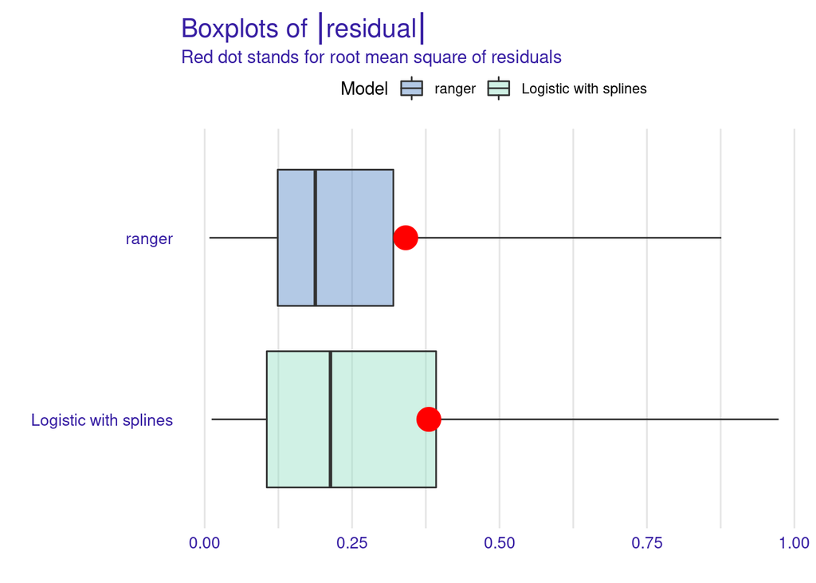

Figure 1: Boxplots for resduals.

```r
plot(mp_ranger, mp_rms, geom = "boxplot")
```

### ROC curves

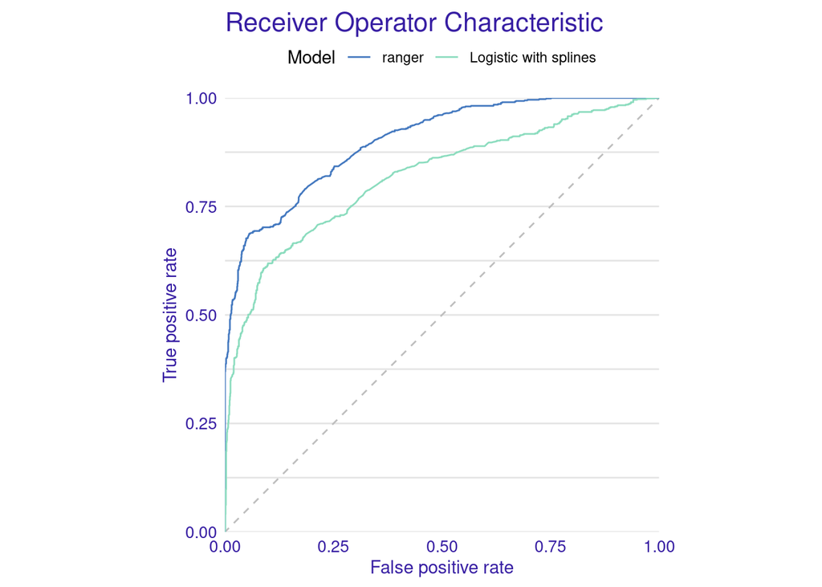

Figure 2: Roc curves.

```r
plot(mp_ranger, mp_rms, geom = "roc")
```

### LIFT curves

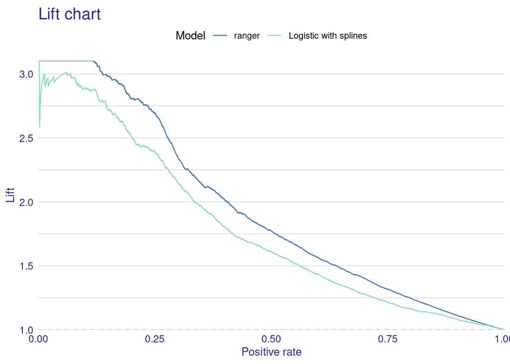

Figure 3: LIFT curves.

```r
plot(mp_ranger, mp_rms, geom = "lift")
```

# Which variables have an impact on a model prediction?

Once we calculate the model prediction, the question often arises which variables had the greatest impact on it.

```r
henry <- titanic_imputed[1,]
predict(exp_ranger, henry)
```

```
         1
0.09955144
```

For linear models it is easy to assess the impact of individual variables because there is one coefficient for each variable. It turns out that such attributions can be calculated for any predictive model. The most popular model agnostic method are Shapley values. They may be calculated with a `predict_parts()` function.

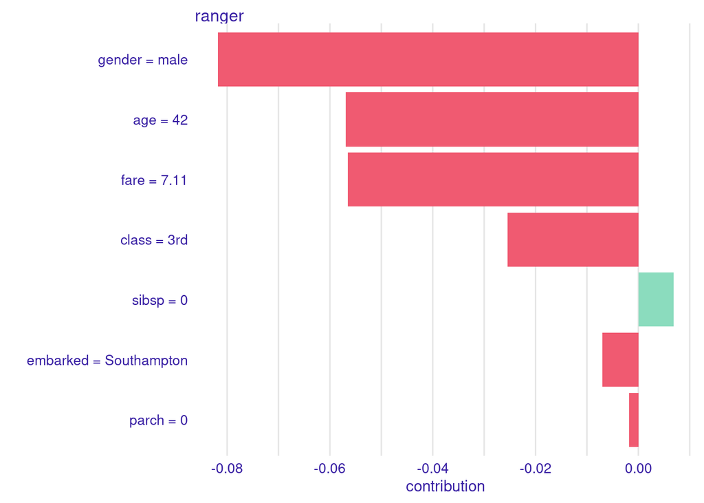

Figure 4: Shapley values assess the impact of each variable on a model prediction. The ttributions add up to model prediction.

```r
sh_ranger <- predict_parts(exp_ranger, henry, type = "shap")
plot(sh_ranger, show_boxplots = FALSE)
```

The Shapley values are additive. For models with interactions, it is often too much of a implification. The Break Down method allows for the identification of interactions.

```r
bd_ranger <- predict_parts(exp_ranger, henry, type = "break_down_interactions")
bd_ranger
```

| variable | contribution | variable_name | variable_value | cumulative | sign | position | label |
| --- | --- | --- | --- | --- | --- | --- | --- |
| intercept | 0.322146585 | intercept | 1 | 0.32214659 | 1 | 8 | ranger |
| gender = male | -0.101253898 | gender | male | 0.22089269 | -1 | 7 | ranger |
| age = 42 | -0.039832448 | age | 42 | 0.18106024 | -1 | 6 | ranger |
| fare:class = 7.11:3rd | -0.067174541 | fare:class | 7.11:3rd | 0.11388570 | -1 | 5 | ranger |
| sibsp = 0 | 0.002329977 | sibsp | 0 | 0.11621568 | 1 | 4 | ranger |
| embarked = Southampton | -0.008822456 | embarked | Southampton | 0.10739322 | -1 | 3 | ranger |
| parch = 0 | -0.007841781 | parch | 0 | 0.09955144 | -1 | 2 | ranger |
| prediction | 0.099551439 |  |  | 0.09955144 | X | 1 | ranger |

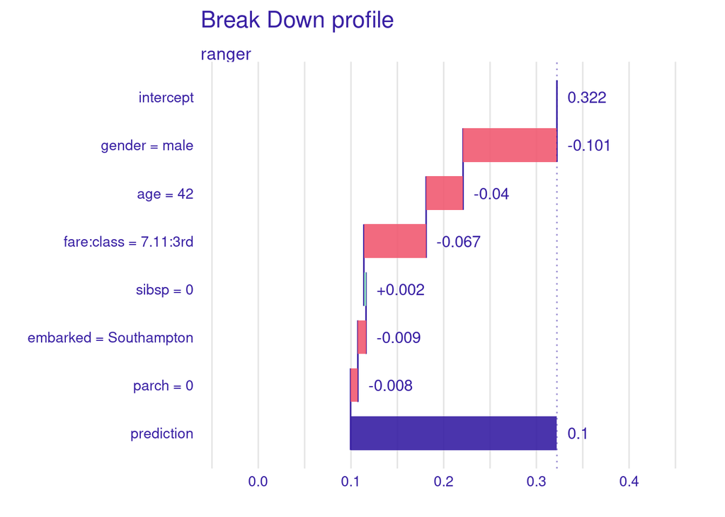

Figure 5: Break down values assess the impact of variable or their interactions on model predictions.

```r
plot(bd_ranger)
```

The show_boxplots argument allows you to highlight the stability bars of the estimated attributions. Other possible values of the type argument are oscillations, shap, break_down, break_down_interactions. With order one can force a certain sequence of variables.

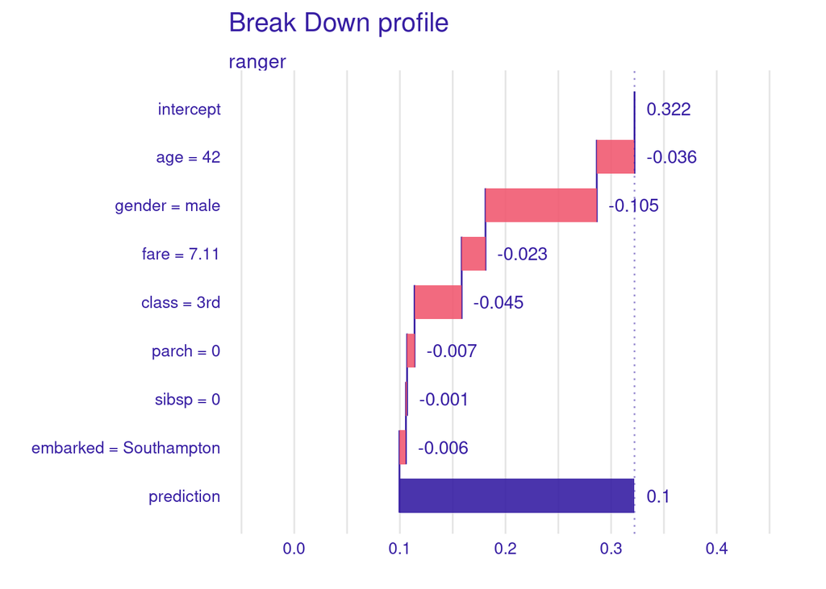

Figure 6: Break down values for selected order of variables.

```r
bd_ranger <- predict_parts(exp_ranger, henry,
order = c("age", "gender", "fare", "class",
          "parch", "sibsp", "embarked"))
plot(bd_ranger)
```

By default, functions such as model_parts, predict_parts, model_profiles do not calculate statistics on the entire data set, but on n_samples of random cases, and the entire procedure is repeated B times to estimate the error bars.

# Which variables have an impact on the model?

Many models have built-in ways of assessing the importance of variables. The procedure described below is universal and does not depend on the model structure.

Note that if a variable is important in a model, then after its permutation the model predictions should be less accurate. The permutation importance of a variable $i$ is the difference between the model performance for the original data and the model performance measured on data with the permutated variable $i$[^5].

The `DALEX::model_parts()` function calculates the importance of variables. The type argument determines whether to subtract (type=“difference”), divide (type=“ratio”) or present original loss functions (type=“raw”).

```r
mp_ranger <- model_parts(exp_ranger, type = "difference")
mp_ranger
```

| variable | permutation | dropout_loss | label |
| --- | --- | --- | --- |
| _full_model_ | 0 | 0.0000000000 | ranger |
| parch | 0 | 0.0188870261 | ranger |
| sibsp | 0 | 0.0209536688 | ranger |
| embarked | 0 | 0.0242522076 | ranger |
| age | 0 | 0.0721382099 | ranger |
| fare | 0 | 0.0862486661 | ranger |
| class | 0 | 0.0965088440 | ranger |
| gender | 0 | 0.2124229339 | ranger |
| _baseline_ | 0 | 0.3956319611 | ranger |
| _full_model_ | 1 | -0.0104174989 | ranger |

[output cut: 89 more lines]

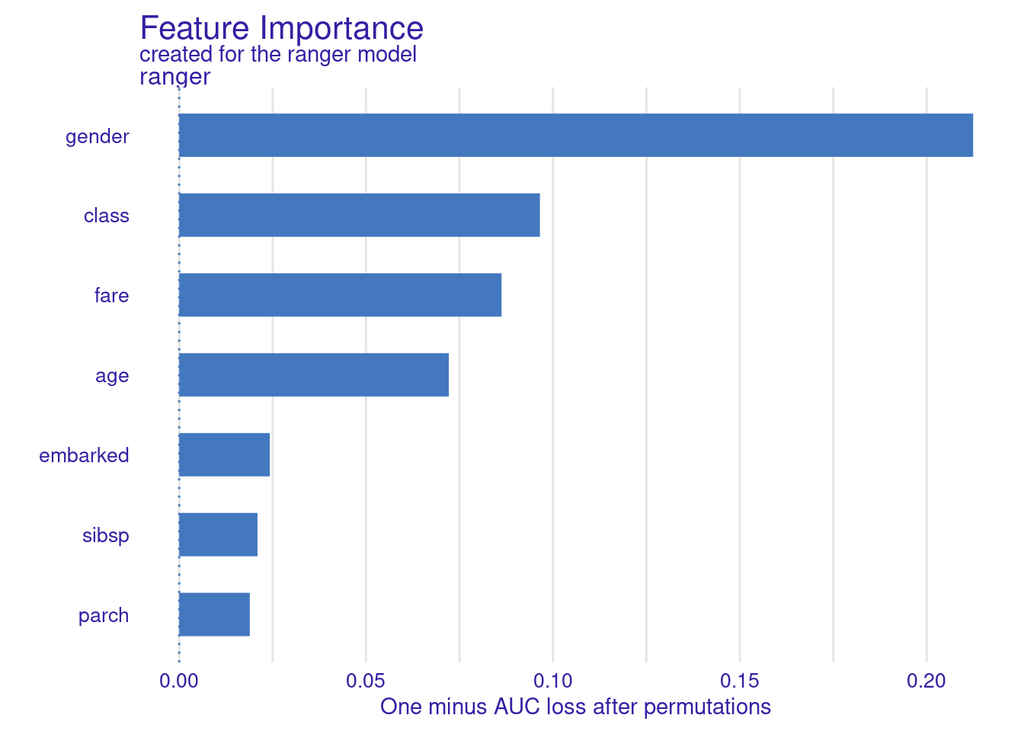

Figure 7: Importance scores $V(f, i)$.

```r
plot(mp_ranger, show_boxplots = FALSE)
```

The importance of variables is a convenient tool to compare models. It is enough to put several importance objects to the generic S3 `plot()` function.

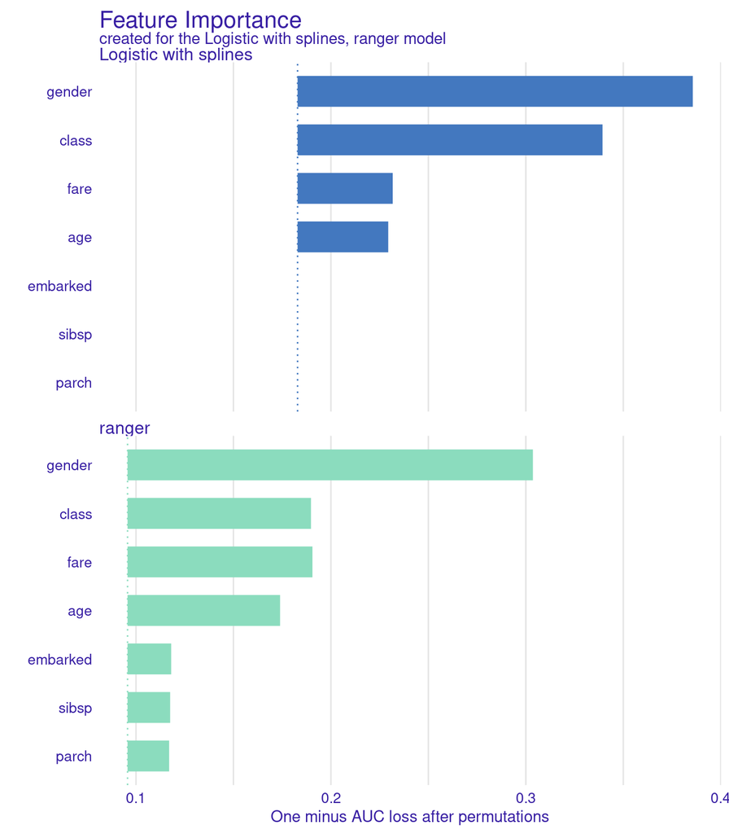

```r
mp_ranger <- model_parts(exp_ranger)
mp_rms <- model_parts(exp_rms)
plot(mp_ranger, mp_rms, show_boxplots = FALSE)
```

By default, $RMSE$ is used for regression and $1-AUC$ for classification problems. But you can change the loss function by specifying the `loss_function` argument.

# What if?

Ceteris-paribus profiles[^6] show how the model response would change for a selected observation if one of the coordinates of that observation were changed while leaving the other coordinates unchanged.

```r
cp_ranger <- predict_profile(exp_ranger, henry)
cp_ranger
```

|  | gender | age | class | embarked | fare | sibsp | parch | _yhat_ | _vname_ | _ids_ | _label_ |
| --- | --- | --- | --- | --- | --- | --- | --- | --- | --- | --- | --- |
| 1 | female | 42.0000000 | 3rd | Southampton | 7.110000 | 0.00 | 0.00 | 0.44733553 | gender | 1 | ranger |
| 1.1 | male | 42.0000000 | 3rd | Southampton | 7.110000 | 0.00 | 0.00 | 0.09955144 | gender | 1 | ranger |
| 11 | male | 0.1666667 | 3rd | Southampton | 7.110000 | 0.00 | 0.00 | 0.49656722 | age | 1 | ranger |
| 1.110 | male | 0.9050000 | 3rd | Southampton | 7.110000 | 0.00 | 0.00 | 0.58435205 | age | 1 | ranger |
| 1.2 | male | 1.6433333 | 3rd | Southampton | 7.110000 | 0.00 | 0.00 | 0.57972341 | age | 1 | ranger |
| 1.3 | male | 2.3816667 | 3rd | Southampton | 7.110000 | 0.00 | 0.00 | 0.58172341 | age | 1 | ranger |
| 1.4 | male | 3.1200000 | 3rd | Southampton | 7.110000 | 0.00 | 0.00 | 0.59155674 | age | 1 | ranger |
| 1.5 | male | 3.8583333 | 3rd | Southampton | 7.110000 | 0.00 | 0.00 | 0.58618375 | age | 1 | ranger |
| 1.6 | male | 4.5966667 | 3rd | Southampton | 7.110000 | 0.00 | 0.00 | 0.57058293 | age | 1 | ranger |
| 1.7 | male | 5.3350000 | 3rd | Southampton | 7.110000 | 0.00 | 0.00 | 0.56808293 | age | 1 | ranger |

[output cut: 407 more lines]

CP profiles can be visualized with the generic `plot()` function.

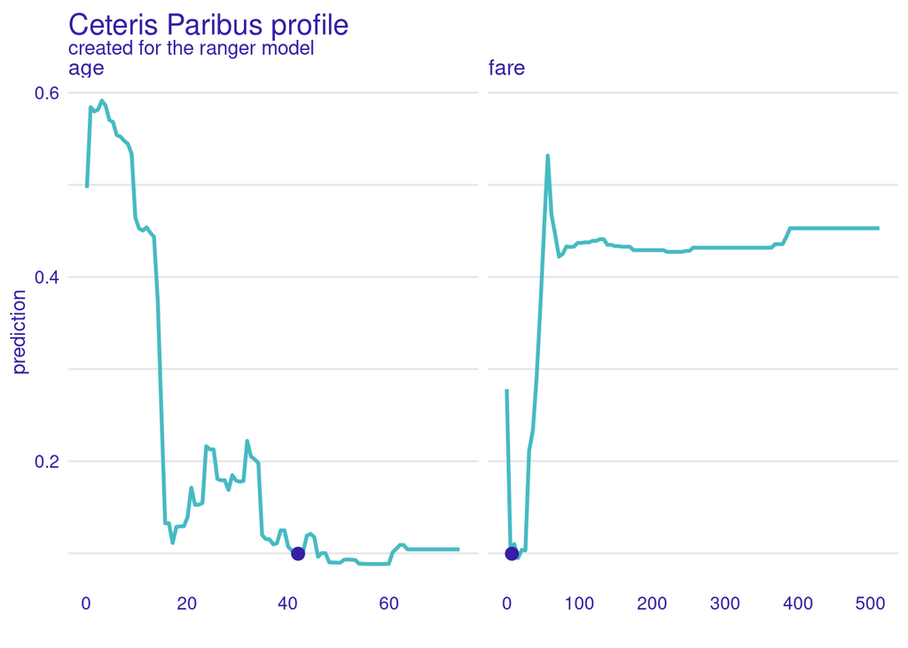

Figure 9: The dot shows the observation under analysis. CP profile shows how the model prediction will change for changes in the selected variable.

```r
plot(cp_ranger, variables = c("age", "fare"))
```

For technical reasons, quantitative and qualitative variables cannot be shown in a single chart. So if you want to show the importance for quality variables you need to plot them separately.

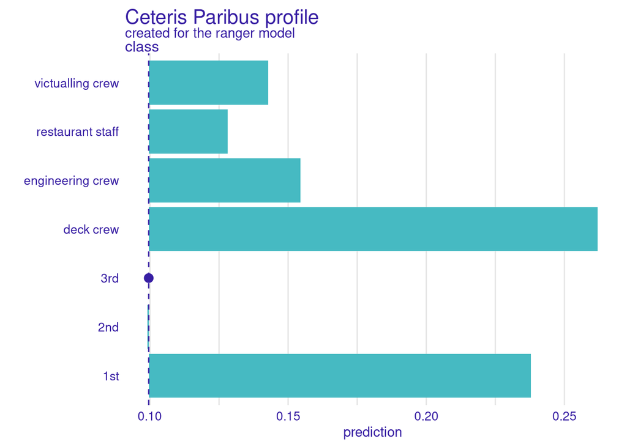

Figure 10: The dot shows the observation under analysis. CP profile shows how the model prediction will change for changes in the selected variable.

```r
plot(cp_ranger, variables = "class", categorical_type = "bars")
```

The `plot` function can combine different models, making it easier to see similarities and differences. The `color` argument allows you to highlight models in the figure.

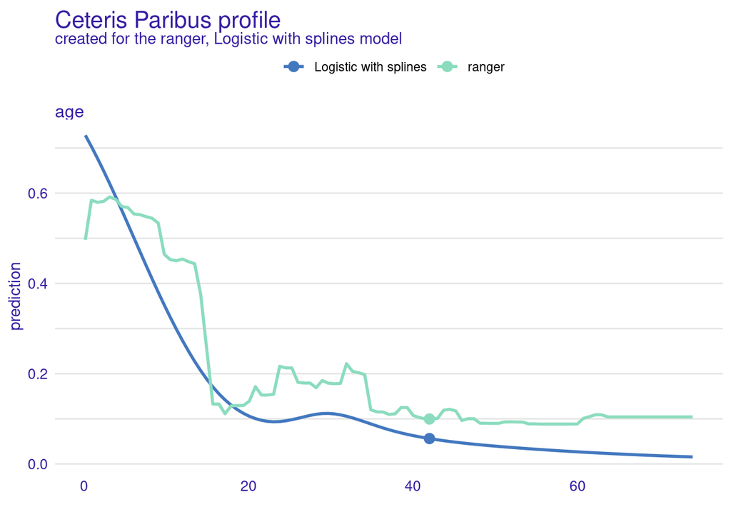

Figure 11: CP profiles for two models.

```r
cp_rms <- predict_profile(exp_rms, henry)
plot(cp_ranger, cp_rms, variables = "age", color = "_label_")
```

## Oscilatons

Local importance of variables can be measured as oscillations of CP plots. The greater the variability of the CP profile, the more important is the variable. Set `type = "oscillations"` in the `predict_parts` function.

```r
predict_parts(exp_rms, henry, type = "oscillations")
```

|  | _vname_ | _ids_ | oscillations |
| --- | --- | --- | --- |
| 1 | gender | 1 | 0.28444819 |
| 3 | class | 1 | 0.13305595 |
| 2 | age | 1 | 0.09284705 |
| 5 | fare | 1 | 0.02086982 |
| 4 | embarked | 1 | 0.00000000 |
| 6 | sibsp | 1 | 0.00000000 |
| 7 | parch | 1 | 0.00000000 |

## Partial dependence profiles

Partial dependence profiles are averages from CP profiles for all (or a large enough number) observations. The `model_profiles()` function calculates PD profiles for a specified model and variables (all by default). Profiles can be then drawn with the plot() function. See an example in Figure 12.

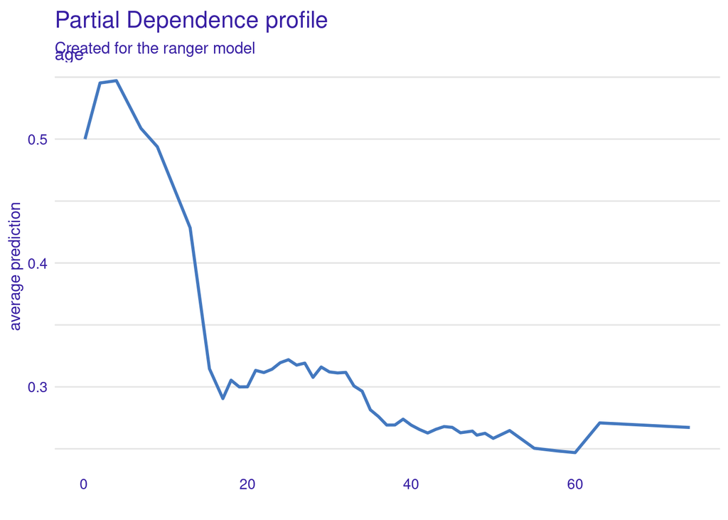

Figure 12: Partial dependence profile for age variable.

```r
mp_ranger <- model_profile(exp_ranger)
plot(mp_ranger, variables = "age")
```

## Grouped partial dependence profiles

By default, the average is calculated for all observations. But with the argument groups= one can specify a factor variable in which CP profiles will be averaged. See an example in Figure Figure 13.

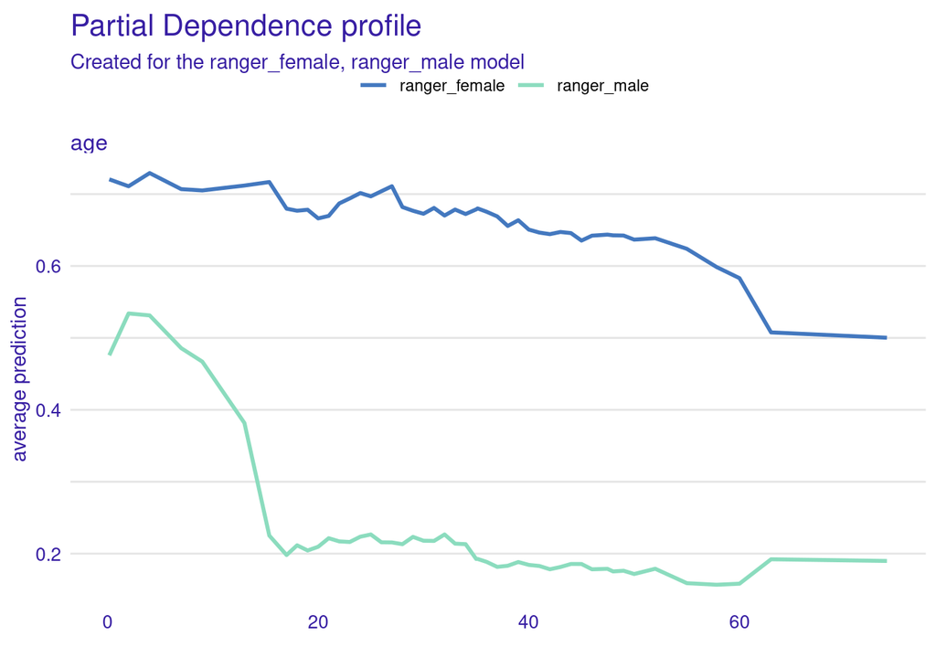

Figure 13: Partial dependence for age in groups defined by gender.

```r
mp_ranger <- model_profile(exp_ranger, groups = "gender")
plot(mp_ranger, variables = "age")
```

If the model is additive, all CP profiles are parallel. But if the model has interactions, CP profiles may have different shapes for different observations. Defining the $k$ argument allows to find and calculate the average in $k$ segments of CP profiles.

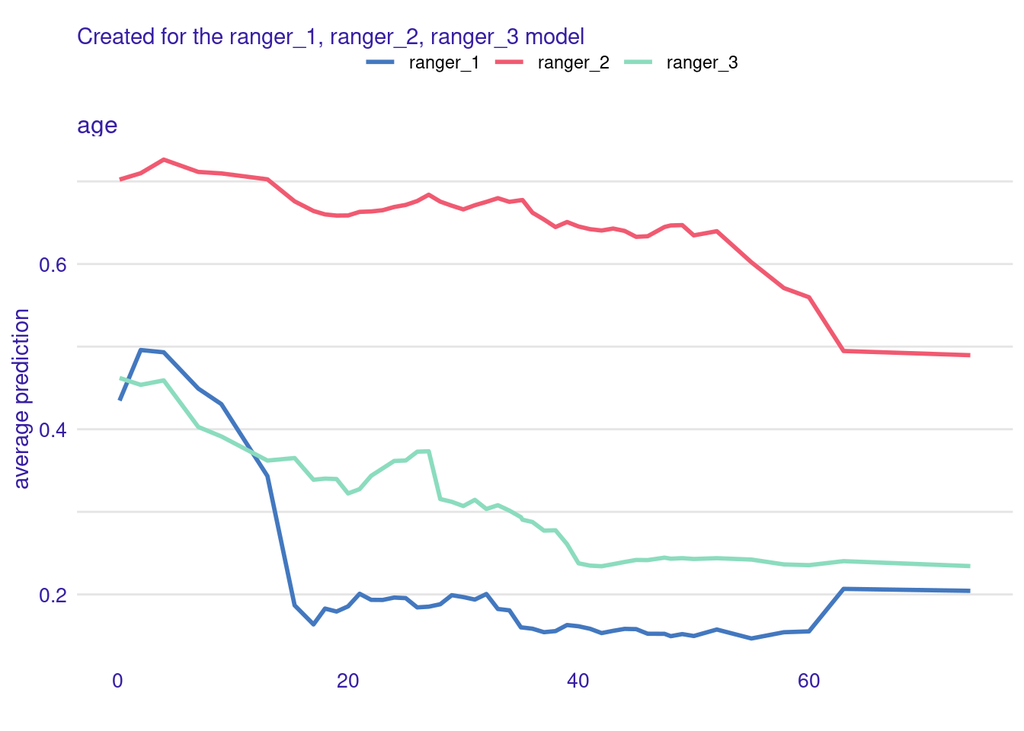

Figure 14: Partial dependence for three segments of CP profiles.

```r
mp_ranger <- model_profile(exp_ranger, k = 3, center = TRUE)
plot(mp_ranger, variables = "age")
```

PDP profiles do not take into account the correlation structure between the variables. For correlated variables, the *Ceteris paribus* assumption may not make sense. The model_profile function can also calculate other types of aggregates, such as marginal profiles and accumulated local profiles. To do this, specify the argument `type= for "conditional"` or `"accumulated"`.

## Footnotes

[^1]: EMA is a subfield of eXplainable Artificial Intelligence. It covers the tools and processes for analysing predictive models in order to better understand their behaviour
[^2]: Instance level = local explanations - methods to explore the model from the perspective of a single prediction.
[^3]: Dataset level = global explanations - analysis of the overall model behaviour, the perspective of a population.
[^4]: Explainer is an object / adapter that wraps the model and creates an uniform tructure and interface for operations.
[^5]: $V(f,i)=L^{i}_{perm}(f)-L_{org}(f)$, where $L_{org}(f)$ is the value of loss functon for original data, while $L^{i}_{perm}(f)$ is the value of loss function after permuted $i-th$ variable.
[^6]: *Ceteris Paribus* is a Latin phrase for “other things being equal”.